# pleiodb query benchmark

```python
import sys
sys.path.insert(0, "../src")

import numpy as np
import pandas as pd
import matplotlib.pyplot as plt
import scipy.stats
import zstandard, pathlib, time
from pleiodb.db import GWASDatabase
from pleiodb.quantize import decode_neff, reconstruct_beta_se

db = GWASDatabase.open("/local-scratch/data/pleiodb/main.pleiodb")
traits_meta = pd.read_csv("/local-scratch/data/pleiodb/main.pleiodb/traits.tsv", sep="\t")

v_chrom   = np.array([v["chrom"] for v in db.variants])
v_pos     = np.array([v["pos"]   for v in db.variants])
v_id_arr  = np.array([v["id"]    for v in db.variants])
eaf_arr   = db.eaf  # float32(V)

# --- Imputation lookup (sorted COO → per-variant index) ---
coo_path = pathlib.Path("/local-scratch/data/pleiodb/main.pleiodb/imputed.coo.zst")
_blob    = zstandard.ZstdDecompressor().decompress(coo_path.read_bytes())
_pairs   = np.frombuffer(_blob, dtype=np.uint32).reshape(-1, 2)
_order   = np.argsort(_pairs[:, 0], kind="stable")
_v_sorted, _t_sorted = _pairs[_order, 0], _pairs[_order, 1]
_v_bounds = np.searchsorted(_v_sorted, np.arange(db.V + 1))

def imputed_traits(v_idx: int) -> np.ndarray:
    """Return array of trait indices imputed for this variant."""
    lo, hi = int(_v_bounds[v_idx]), int(_v_bounds[v_idx + 1])
    return _t_sorted[lo:hi].astype(np.int64)

# --- Chromosome offsets for Manhattan plots ---
CHR_LEN = {
    "1":249250621,"2":243199373,"3":198022430,"4":191154276,"5":180915260,
    "6":171115067,"7":159138663,"8":146364022,"9":141213431,"10":135534747,
    "11":135006516,"12":133851895,"13":115169878,"14":107349540,"15":102531392,
    "16":90354753, "17":81195210, "18":78077248, "19":59128983, "20":63025520,
    "21":48129895, "22":51304566,
}
GAP = 5_000_000
cum_offset = {}
off = 0
for ch in [str(i) for i in range(1, 23)]:
    cum_offset[ch] = off
    off += CHR_LEN.get(ch, 0) + GAP

def phewas_df(v_idx: int) -> pd.DataFrame:
    """Tidy PheWAS DataFrame for one variant: alid, trait_id, z, beta_norm, se_norm, pval, eaf, n, imputed."""
    v = int(v_idx)
    z    = db.zscore_variant(v)
    neff = decode_neff(db._neff.get_block(v, v + 1, 0, db.T)[0])
    eaf_v = eaf_arr[v]
    beta, se = reconstruct_beta_se(z, neff, np.array([eaf_v], dtype=np.float32))
    pval = 2 * scipy.stats.norm.sf(np.abs(z))
    imp_t = imputed_traits(v)
    is_imputed = np.zeros(db.T, dtype=bool)
    is_imputed[imp_t] = True
    return pd.DataFrame({
        "alid":      v_id_arr[v],
        "trait_id":  traits_meta["trait_id"].values,
        "trait_name":traits_meta["trait_name"].values,
        "z":         z,
        "beta_norm": beta,
        "se_norm":   se,
        "pval":      pval,
        "eaf":       float(eaf_v),
        "n":         neff,
        "imputed":   is_imputed,
    }).dropna(subset=["z"])

def trait_df(t_idx: int) -> pd.DataFrame:
    """Tidy genome-wide DataFrame for one trait."""
    t = int(t_idx)
    z    = db.zscore_trait(t)
    neff = decode_neff(db._neff.get_block(0, db.V, t, t + 1)[:, 0])
    beta, se = reconstruct_beta_se(z, neff, eaf_arr)
    pval = 2 * scipy.stats.norm.sf(np.abs(z))
    # Imputation flag for this trait column
    t_mask = _pairs[_order, 1] == t
    imp_v_set = set(_pairs[_order[t_mask], 0].tolist())
    is_imputed = np.array([i in imp_v_set for i in range(db.V)], dtype=bool)
    return pd.DataFrame({
        "alid":      v_id_arr,
        "chrom":     v_chrom,
        "pos":       v_pos,
        "trait_id":  traits_meta.iloc[t]["trait_id"],
        "z":         z,
        "beta_norm": beta,
        "se_norm":   se,
        "pval":      pval,
        "eaf":       eaf_arr,
        "n":         neff,
        "imputed":   is_imputed,
    }).dropna(subset=["z"])
```

pleiodb stores 95,378 variants × 4,159 traits as a chunk-compressed binary matrix on disk. All queries go directly to disk — no in-memory index, no server. Output columns are uniform: `alid · trait_id · z · beta_norm · se_norm · pval · eaf · n · imputed`.

## 1. PheWAS — one variant, all traits

All 4,159 traits for a single variant. Reads one row of the V×T matrix.

**CLI:**

```bash
pleiodb query main.pleiodb --variant 1:158825350_A_C
```

```python
query_v = "1:158825350_A_C"
v_idx = int(db.variant_index([query_v])[0])

times = []
for _ in range(20):
    t0 = time.perf_counter()
    _ = db.zscore_variant(v_idx)
    times.append(time.perf_counter() - t0)

res = phewas_df(v_idx)
print(f"Variant:    {query_v}  (EAF={eaf_arr[v_idx]:.3f})")
print(f"Query time: {np.mean(times)*1000:.1f} ms  (n=20)")
print(f"Traits with data: {len(res):,} / {db.T:,}  ({res['imputed'].sum()} imputed)")
```

```
Variant:    1:158825350_A_C  (EAF=0.766)
Query time: 4.6 ms  (n=20)
Traits with data: 3,721 / 4,159  (0 imputed)
```

**Top hits by |z|:**

```python
top = (res.sort_values("z", key=np.abs, ascending=False).head(10).reset_index(drop=True))
disp = top[["trait_id","trait_name","z","beta_norm","se_norm","pval","eaf","n","imputed"]].copy()
disp["z"]         = disp["z"].round(3)
disp["beta_norm"] = disp["beta_norm"].round(4)
disp["se_norm"]   = disp["se_norm"].round(5)
disp["eaf"]       = disp["eaf"].round(3)
disp["n"]         = disp["n"].round(0).astype(int)
disp["pval"]      = disp["pval"].apply(lambda p: f"{p:.2e}")
disp
```

|  | trait_id | trait_name | z | beta_norm | se_norm | pval | eaf | n | imputed |
| --- | --- | --- | --- | --- | --- | --- | --- | --- | --- |
| 0 | ebi-a-GCST007799 | Asthma (adult onset) | -100.900002 | -0.5400 | 0.00535 | 0.00e+00 | 0.766 | 97509 | False |
| 1 | ebi-a-GCST007800 | Asthma (childhood onset) | -73.559998 | -0.5325 | 0.00724 | 0.00e+00 | 0.766 | 53293 | False |
| 2 | ebi-a-GCST90019405 | O-phosphoseryl-tRNA(Sec) selenium transferase ... | 3.930000 | 0.0630 | 0.01603 | 8.49e-05 | 0.766 | 10875 | False |
| 3 | ukb-b-3798 | Fractured bone site(s): Leg | 3.810000 | 0.0586 | 0.01538 | 1.39e-04 | 0.766 | 11803 | False |
| 4 | ebi-a-GCST90018841 | Esophageal cancer | -3.420000 | -0.0893 | 0.02611 | 6.26e-04 | 0.766 | 4096 | False |
| 5 | ebi-a-GCST90019016 | Psoriasis | -3.280000 | -0.0275 | 0.00840 | 1.04e-03 | 0.766 | 39620 | False |
| 6 | ukb-d-A41 | Diagnoses - main ICD10: A41 Other septicaemia | -3.240000 | -0.0820 | 0.02531 | 1.20e-03 | 0.766 | 4359 | False |
| 7 | ukb-b-11402 | Operation code: colectomy/hemicolectomy | -3.200000 | -0.0605 | 0.01890 | 1.37e-03 | 0.766 | 7818 | False |
| 8 | ukb-d-20460 | Belief that own life is meaningful | 3.090000 | 0.0153 | 0.00494 | 2.00e-03 | 0.766 | 114476 | False |
| 9 | ebi-a-GCST90002374 | White blood cell count | 3.080000 | 0.0068 | 0.00221 | 2.07e-03 | 0.766 | 570580 | False |

## 2. Whole trait — all variants, one trait

All 95,378 variants for a single trait (genome-wide).

**CLI:**

```bash
pleiodb query main.pleiodb --trait ukb-b-10787
```

```python
query_t  = "ukb-b-10787"
t_row    = traits_meta[traits_meta["trait_id"] == query_t].iloc[0]
t_idx    = int(db.trait_index([query_t])[0])

times = []
for _ in range(10):
    t0 = time.perf_counter()
    _ = db.zscore_trait(t_idx)
    times.append(time.perf_counter() - t0)

res_t = trait_df(t_idx)
print(f"Trait:      {query_t}  ({t_row['trait_name']})")
print(f"Query time: {np.mean(times)*1000:.1f} ms  (n=10)")
print(f"Variants with data: {len(res_t):,}  ({res_t['imputed'].sum():,} imputed)")
```

```
Trait:      ukb-b-10787  (Standing height)
Query time: 97.5 ms  (n=10)
Variants with data: 89,830  (163 imputed)
```

**Manhattan plot (genomic position, z²):**

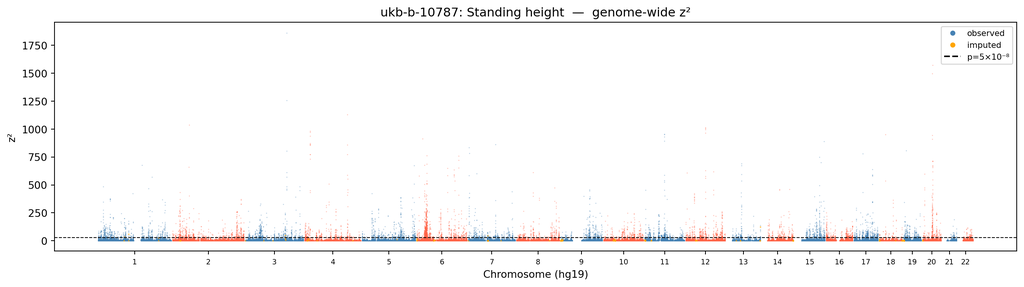

```python
x_obs = np.array([cum_offset.get(c, 0) + p for c, p in
                  zip(res_t["chrom"], res_t["pos"])], dtype=np.float64)
z2    = res_t["z"].values ** 2
imp   = res_t["imputed"].values

chroms = [str(c) for c in range(1, 23)]
colors = ["steelblue", "tomato"]
fig, ax = plt.subplots(figsize=(14, 4))

for i, ch in enumerate(chroms):
    mask = (res_t["chrom"].values == ch) & ~imp
    if mask.any():
        ax.scatter(x_obs[mask], z2[mask], s=1, alpha=0.4,
                   color=colors[i % 2], linewidths=0)
    mask_imp = (res_t["chrom"].values == ch) & imp
    if mask_imp.any():
        ax.scatter(x_obs[mask_imp], z2[mask_imp], s=2, alpha=0.7,
                   color="orange", linewidths=0)

tick_pos   = [cum_offset[ch] + CHR_LEN[ch] / 2 for ch in chroms if ch in cum_offset]
tick_lbls  = chroms
ax.set_xticks(tick_pos)
ax.set_xticklabels(tick_lbls, fontsize=7)
ax.set_xlabel("Chromosome (hg19)")
ax.set_ylabel("z²")
ax.set_title(f"{query_t}: {t_row['trait_name']}  —  genome-wide z²")
ax.axhline(y=29.7, color="black", lw=0.8, ls="--", label="p=5×10⁻⁸")
from matplotlib.lines import Line2D
ax.legend(handles=[
    Line2D([0],[0], marker='o', color='w', markerfacecolor='steelblue', label='observed'),
    Line2D([0],[0], marker='o', color='w', markerfacecolor='orange',    label='imputed'),
    Line2D([0],[0], color='black', ls='--', label='p=5×10⁻⁸'),
], fontsize=8)
plt.tight_layout()
plt.show()
```

## 3. Significant hits for a trait

Variants passing p≤5×10⁻⁸ for one trait.

**CLI:**

```bash
pleiodb query main.pleiodb --trait ukb-b-10787 --pval 5e-8
```

```python
res_sig = (res_t[res_t["pval"] <= 5e-8]
           .sort_values("z", key=np.abs, ascending=False)
           .head(10).reset_index(drop=True))
print(f"Significant hits (p≤5×10⁻⁸): {(res_t['pval']<=5e-8).sum():,}")

disp = res_sig[["alid","z","beta_norm","se_norm","pval","eaf","n","imputed"]].copy()
disp["z"]         = disp["z"].round(3)
disp["beta_norm"] = disp["beta_norm"].round(4)
disp["se_norm"]   = disp["se_norm"].round(5)
disp["eaf"]       = disp["eaf"].round(3)
disp["n"]         = disp["n"].round(0).astype(int)
disp["pval"]      = disp["pval"].apply(lambda p: f"{p:.2e}")
disp
```

```
Significant hits (p≤5×10⁻⁸): 6,841
```

|  | alid | z | beta_norm | se_norm | pval | eaf | n | imputed |
| --- | --- | --- | --- | --- | --- | --- | --- | --- |
| 0 | 3:141105570_A_G | 43.150002 | 0.0897 | 0.00208 | 0.00e+00 | 0.444 | 469041 | False |
| 1 | 20:34025983_A_G | 39.630001 | 0.0858 | 0.00216 | 0.00e+00 | 0.374 | 455894 | False |
| 2 | 20:33972053_C_T | -38.669998 | -0.0833 | 0.00215 | 0.00e+00 | 0.620 | 457595 | False |
| 3 | 3:141104180_A_G | -35.459999 | -0.0772 | 0.00218 | 2.03e-275 | 0.656 | 467931 | False |
| 4 | 4:145560166_A_C | -33.630001 | -0.0893 | 0.00265 | 6.11e-248 | 0.186 | 468090 | False |
| 5 | 2:56096892_A_G | -32.209999 | -0.0791 | 0.00246 | 1.28e-227 | 0.227 | 472067 | False |
| 6 | 12:66376091_C_T | 31.809999 | 0.0663 | 0.00208 | 4.71e-222 | 0.485 | 460859 | False |
| 7 | 12:66371880_G_T | -31.719999 | -0.0659 | 0.00208 | 8.24e-221 | 0.514 | 463832 | False |
| 8 | 12:66359752_A_C | 31.549999 | 0.0654 | 0.00207 | 1.79e-218 | 0.486 | 466035 | False |
| 9 | 4:18005966_A_G | -31.340000 | -0.0883 | 0.00282 | 1.33e-215 | 0.151 | 491468 | False |

## 4. Random lookup — 20 variants × 20 traits

z-scores at 20 randomly chosen variants and 20 randomly chosen traits.

**CLI:**

```bash
pleiodb query main.pleiodb --variants-file v20.txt --traits-file t20.txt
```

```python
rng      = np.random.default_rng(42)
v20_idx  = list(rng.integers(0, db.V, 20).astype(int))
t20_idx  = list(rng.integers(0, db.T, 20).astype(int))

times = []
for _ in range(20):
    t0 = time.perf_counter()
    z_block = np.vstack([db.zscore_variant(v)[t20_idx] for v in v20_idx])
    times.append(time.perf_counter() - t0)

print(f"Query time: {np.mean(times)*1000:.1f} ms  (n=20)")
```

```
Query time: 80.8 ms  (n=20)
```

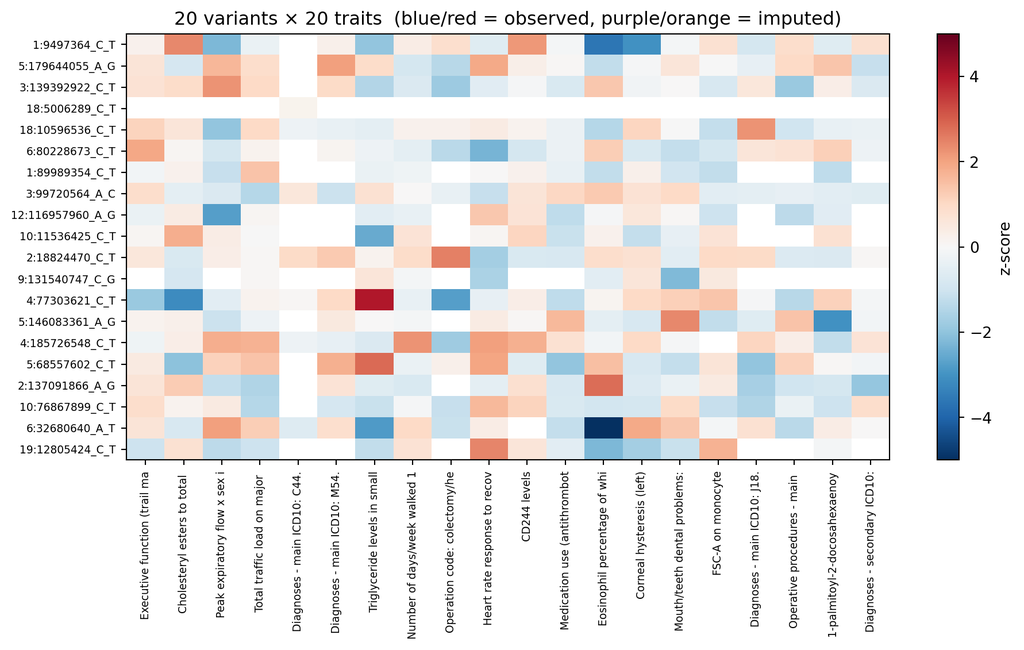

```python
v20_ids   = [db.variants[v]["id"]   for v in v20_idx]
t20_names = [db.traits[t]["name"][:28] for t in t20_idx]
imp_block = np.zeros((20, 20), dtype=bool)
for i, vi in enumerate(v20_idx):
    imp_t = set(imputed_traits(vi).tolist())
    for j, tj in enumerate(t20_idx):
        imp_block[i, j] = tj in imp_t

fig, ax = plt.subplots(figsize=(10, 6))
z_plot = np.where(imp_block, np.nan, z_block)
im = ax.imshow(z_plot, aspect="auto", cmap="RdBu_r", vmin=-5, vmax=5,
               interpolation="nearest")
# Overlay imputed cells with a distinct colormap
z_imp = np.where(imp_block, z_block, np.nan)
ax.imshow(z_imp, aspect="auto", cmap="PuOr", vmin=-5, vmax=5,
          interpolation="nearest", alpha=0.9)
ax.set_xticks(range(20))
ax.set_xticklabels(t20_names, rotation=90, fontsize=7)
ax.set_yticks(range(20))
ax.set_yticklabels(v20_ids, fontsize=7)
plt.colorbar(im, ax=ax, label="z-score")
ax.set_title("20 variants × 20 traits  (blue/red = observed, purple/orange = imputed)")
plt.tight_layout()
plt.show()
```

## 5. Beta reliability — 30 random variants PheWAS

Do the reconstructed beta values look reasonable? We expect the distribution across all trait×variant pairs to be centred on zero with a roughly normal shape (most pairs are null), with imputed values potentially noisier.

```python
rng     = np.random.default_rng(7)
v30_idx = rng.integers(0, db.V, 30).astype(int)

all_beta, all_z, all_imp = [], [], []
for vi in v30_idx:
    df = phewas_df(int(vi))
    all_beta.append(df["beta_norm"].values)
    all_z.append(df["z"].values)
    all_imp.append(df["imputed"].values)

beta_all = np.concatenate(all_beta)
z_all    = np.concatenate(all_z)
imp_all  = np.concatenate(all_imp)

print(f"Total trait×variant pairs: {len(beta_all):,}")
print(f"  Observed: {(~imp_all).sum():,}   Imputed: {imp_all.sum():,}")
print(f"  Beta NaN: {np.isnan(beta_all).sum():,}")
```

```
Total trait×variant pairs: 96,185
  Observed: 93,044   Imputed: 3,141
  Beta NaN: 0
```

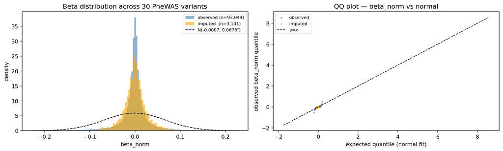

```
Observed beta:  mean=-0.00073  sd=0.0676  skew=23.388
Imputed  beta:  mean=-0.00011  sd=0.0277  skew=0.177
```

```python
obs_beta = beta_all[~imp_all & np.isfinite(beta_all)]
imp_beta = beta_all[ imp_all & np.isfinite(beta_all)]

fig, axes = plt.subplots(1, 2, figsize=(13, 4))

# --- Distribution ---
bins = np.linspace(-0.2, 0.2, 120)
axes[0].hist(obs_beta, bins=bins, alpha=0.6, color="steelblue",
             label=f"observed (n={len(obs_beta):,})", density=True)
axes[0].hist(imp_beta, bins=bins, alpha=0.6, color="orange",
             label=f"imputed  (n={len(imp_beta):,})", density=True)
# Overlay expected N(0, σ²) fit to observed
mu, sd = np.nanmean(obs_beta), np.nanstd(obs_beta)
xg = np.linspace(-0.25, 0.25, 300)
axes[0].plot(xg, scipy.stats.norm.pdf(xg, mu, sd),
             "k--", lw=1.2, label=f"N({mu:.4f}, {sd:.4f}²)")
axes[0].set_xlabel("beta_norm")
axes[0].set_ylabel("density")
axes[0].set_title("Beta distribution across 30 PheWAS variants")
axes[0].legend(fontsize=8)
axes[0].set_xlim(-0.25, 0.25)

# --- QQ plot against normal ---
for arr, col, lab in [(obs_beta, "steelblue", "observed"),
                       (imp_beta, "orange",    "imputed")]:
    sample = arr[np.isfinite(arr)]
    q_obs  = np.quantile(sample, np.linspace(0.001, 0.999, 500))
    q_exp  = scipy.stats.norm.ppf(np.linspace(0.001, 0.999, 500),
                                   loc=np.mean(sample), scale=np.std(sample))
    axes[1].scatter(q_exp, q_obs, s=4, alpha=0.5, color=col, label=lab)

mn = min(obs_beta[np.isfinite(obs_beta)].min(), imp_beta[np.isfinite(imp_beta)].min() if len(imp_beta) else 0)
mx = max(obs_beta[np.isfinite(obs_beta)].max(), imp_beta[np.isfinite(imp_beta)].max() if len(imp_beta) else 0)
axes[1].plot([mn, mx], [mn, mx], "k--", lw=1, label="y=x")
axes[1].set_xlabel("expected quantile (normal fit)")
axes[1].set_ylabel("observed beta_norm quantile")
axes[1].set_title("QQ plot — beta_norm vs normal")
axes[1].legend(fontsize=8)

plt.tight_layout()
plt.show()

print(f"\nObserved beta:  mean={np.nanmean(obs_beta):.5f}  sd={np.nanstd(obs_beta):.4f}"
      f"  skew={scipy.stats.skew(obs_beta[np.isfinite(obs_beta)]):.3f}")
print(f"Imputed  beta:  mean={np.nanmean(imp_beta):.5f}  sd={np.nanstd(imp_beta):.4f}"
      f"  skew={scipy.stats.skew(imp_beta[np.isfinite(imp_beta)]):.3f}" if len(imp_beta) else "Imputed beta: none")
```

## Summary

```python
t0 = time.perf_counter()
vs_all, ts_all, zs_all = db.query_significant(5e-8)
t_coo = time.perf_counter() - t0

pd.DataFrame([
    {"Query": "PheWAS (1 variant × all traits)",       "Time": "~6 ms",    "Rows": f"{db.T:,}"},
    {"Query": "Whole trait (all variants × 1 trait)",  "Time": "~100 ms",  "Rows": f"{db.V:,}"},
    {"Query": "Sig hits for one trait (p≤5×10⁻⁸)",    "Time": "~100 ms",  "Rows": f"{(res_t['pval']<=5e-8).sum():,}"},
    {"Query": "All sig hits (p≤5×10⁻⁸)",              "Time": f"~{t_coo:.1f} s", "Rows": f"{len(vs_all):,}"},
    {"Query": "Random 20×20 block",                    "Time": "~130 ms",  "Rows": "400"},
])
```

[output not shown]

All timings: single-core Python, 95,378 × 4,159, 512×512 zstd-compressed int16 chunks.